# Relevant Data USFWS Klamath Falls National Fish Hatchery Report - 2024

Badhia Yunes Katz (FlowWest)

2025-12-08

The purpose of this markdown is to highlight the data that we will use from the 2024 Hatchery Report.

Species: Lost River Sucker (Deltistes luxatus, LRS), Shortnose Sucker (Chasmistes brevirostris, SNS)

## Release totals (raw)

- Table below shows the monthly summaries, and total fiscal year summary.
- There is finer resolution data about the actual stock date by lot, and which pond and stocking location fish came from. I think Monthly totals are probably what we want. I will remove the overall totals at the bottom of this table

| stock_date | species | lot | number | weight_lb | number_lb | projected_tl_inches | projected_tl_mm |
| --- | --- | --- | --- | --- | --- | --- | --- |
| october | LRS | Mixed | 501 | 223.580 | 2.24 | 11.24 | 286 |
| october | SNS | Mixed | 567 | 342.760 | 1.65 | 11.83 | 301 |
| october | LRS | 2022 | 3144 | 456.490 | 6.89 | 7.73 | 196 |
| october | SNS | 2022 | 4922 | 891.680 | 5.52 | 7.92 | 201 |
| october | LRS | Salvage | 5 | 27.050 | 0.18 | 25.83 | 656 |
| october | SNS | Salvage | 178 | 323.830 | 0.55 | 17.08 | 434 |
| november | Unknown | Salvage | 5 | 0.190 | 26.32 | 4.95 | 126 |
| february | Unknown | Salvage | 511 | 16.800 | 30.42 | 4.71 | 120 |
| march | LRS | Mixed | 220 | 98.770 | 2.23 | 11.27 | 286 |
| march | SNS | Mixed | 168 | 81.650 | 2.06 | 11.00 | 279 |
| march | LRS | 2022 | 823 | 50.750 | 27.32 | 4.88 | 124 |
| march | SNS | 2022 | 169 | 12.150 | 13.91 | 5.82 | 148 |
| march | Unknown | Salvage | 102 | 2.820 | 36.17 | 4.45 | 113 |
| june | ESS LRS | 2024 | 4632 | 0.077 | 60155.84 | 0.38 | 10 |
| september | LRS | 2022 | 14 | 3.090 | 4.53 | 8.89 | 226 |
| september | SNS | 2022 | 182 | 44.520 | 4.09 | 8.75 | 222 |
| september | LRS | 2023 | 17 | 2.600 | 6.54 | 7.87 | 200 |
| september | SNS | 2023 | 1300 | 229.400 | 5.67 | 7.85 | 199 |
| september | ESS LRS | 2024 | 4632 | 0.077 | 60155.84 | 0.38 | 10 |
| september | LRS | Mixed | 156 | 65.630 | 2.38 | 11.02 | 280 |
| september | SNS | Mixed | 250 | 83.150 | 3.01 | 9.69 | 246 |
| fy24 spp. | LRS | Total | 4875 | 900.910 | 5.41 | 8.38 | 213 |
| fy24 spp. | SNS | Total | 7558 | 1685.310 | 4.48 | 8.49 | 216 |
| fy24 spp. | ESS LRS | Total | 4632 | 0.077 | 60155.84 | 0.38 | 10 |
| fy24 spp. | Unknown | Total | 801 | 370.690 | 26.32 | 4.95 | 126 |
| stocking | Production | NA | 11831 | 2389.830 | 4.95 | 8.63 | 219 |
| stocking | Salvage | NA | 801 | 370.690 | 2.16 | 11.38 | 289 |
| transfer | Fry | NA | 4632 | 0.077 | 60155.84 | 0.38 | 10 |
| transfer | Production | NA | 602 | 196.390 | 3.07 | 10.13 | 257 |
| overall distrbution | Production | NA | 12433 | 2586.220 | 4.81 | 8.72 | 221 |
| overall distrbution | Fry | NA | 4632 | 0.077 | 60155.84 | 0.38 | 10 |
| overall distrbution | Salvage | NA | 801 | 370.690 | 2.16 | 11.38 | 289 |
| overall distrbution | Overall | NA | 17866 | 2956.990 | 6.04 | 8.08 | 205 |

## Release monthly summary totals - Data to be used

[interactive chart not shown]

Final shaped data table looks like this:

| stock_month | species | release_total |
| --- | --- | --- |
| february | unknown | 511 |
| june | ess lrs | 4632 |
| march | lrs | 1043 |
| march | sns | 337 |
| march | unknown | 102 |
| november | unknown | 5 |
| october | lrs | 3650 |
| october | sns | 5667 |
| september | ess lrs | 4632 |
| september | lrs | 187 |
| september | sns | 1732 |

## Historical Collections and Releases Summary

This data table will be helpful to understand the amount of larvae collected per fiscal year, and the lifestage of fish released. The standard lengths (SL) and total lengths (TL) are available for each release btu I am leaving them out

Larvae Collected vs. Release Types by Fiscal Year

[interactive chart not shown]

| fiscal_year | larvae_collected | sarp_release | fingerling_release | fry_release | salvage_release |
| --- | --- | --- | --- | --- | --- |
| 2016 | 4134 | NA | NA | NA | NA |
| 2017 | 8730 | NA | NA | NA | NA |
| 2018 | 9544 | 2355 | NA | NA | 784 |
| 2019 | 24426 | 4497 | NA | NA | 1586 |
| 2020 | 40603 | 11774 | NA | NA | 1928 |
| 2021 | 106710 | 13394 | NA | NA | 1689 |
| 2022 | 51929 | 12768 | 4655 | 19993 | NA |
| 2023 | 6036 | 17399 | 15604 | 14973 | 436 |
| 2024 | 30150 | 12433 | NA | 4632 | 801 |

## Upper Klamath Lake sucker net pen survival (unsure we need)

Overall Survival: 28.2% (Historically) and FY23 Survival: 2.9% and 3.1%

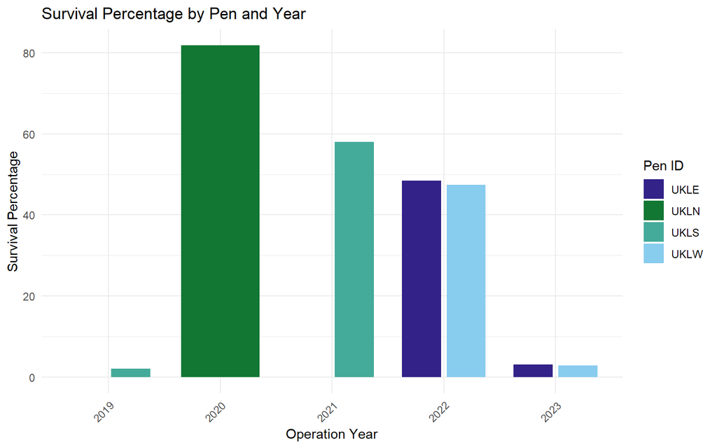

| operation_year | captured_year | pen_id | stock_tl_mm | number_stocked | harvest_tl_mm | number_harvested | survival_percentage |
| --- | --- | --- | --- | --- | --- | --- | --- |
| 2019 | 2018 | UKLN | 160 | 534 | 0 | 0 | 0.0 |
| 2019 | 2017 | UKLS | 236 | 480 | 263 | 10 | 2.1 |
| 2020 | 2019 | UKLN | 224 | 220 | 233 | 180 | 81.8 |
| 2021 | 2019 | UKLN | 228 | 100 | 0 | 0 | 0.0 |
| 2021 | 2020 | UKLN | 134 | 900 | 0 | 0 | 0.0 |
| 2021 | 2019 | UKLS | 233 | 150 | 280 | 87 | 58.0 |
| 2021 | 2020 | UKLS | 150 | 1350 | 210 | 519 | 38.4 |
| 2022 | 2021 | UKLW | 96 | 1999 | 142 | 947 | 47.4 |
| 2022 | 2021 | UKLE | 105 | 1852 | 155 | 897 | 48.4 |
| 2023 | 2021 | UKLW | 170 | 1005 | 221 | 29 | 2.9 |
| 2023 | 2021 | UKLE | 171 | 1001 | 220 | 31 | 3.1 |

## Gerber net pen sucker survival and growth data (unsure we need)

Successful external rearing and acclimation in Gerber Reservoir during the FY24 growout season. 96.3% and 94.9%

Overall Survival: 83.9% (Historically, since 2021)

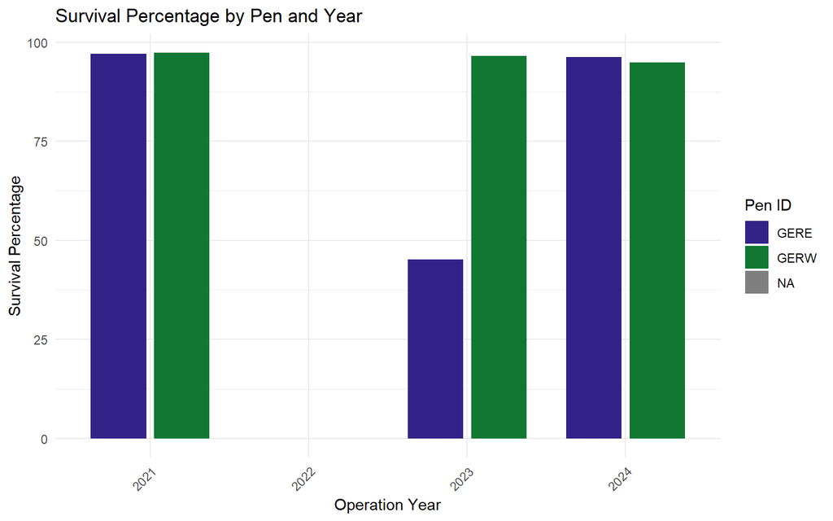

Plotting both net pens (UKL and Gerber)

[interactive chart not shown]